# Risk Factor Analysis

## Outcome Variable

**Outcome Variable:** ever_stunted

## Predictor Variables

**Intervention Variable:** hhwealth_quart

**Adjustment Set:**

- arm
- sex
- W_mage
- meducyrs
- feducyrs
- W_gagebrth
- W_birthwt
- W_birthlen
- W_nchldlt5
- W_parity
- delta_sex
- delta_W_mage
- delta_meducyrs
- delta_feducyrs
- delta_W_gagebrth
- delta_W_birthwt
- delta_W_birthlen
- delta_W_nchldlt5
- delta_W_parity

## Stratifying Variables

The analysis was stratified on these variable(s):

- agecat
- studyid
- country

## Data Summary

| agecat | studyid | country | hhwealth_quart | ever_stunted | n_cell | n |
| --- | --- | --- | --- | --- | --- | --- |
| 0-24 months | CMC-V-BCS-2002 | INDIA | Wealth Q4 | 0 | 6 | 373 |
| 0-24 months | CMC-V-BCS-2002 | INDIA | Wealth Q4 | 1 | 90 | 373 |
| 0-24 months | CMC-V-BCS-2002 | INDIA | Wealth Q1 | 0 | 6 | 373 |
| 0-24 months | CMC-V-BCS-2002 | INDIA | Wealth Q1 | 1 | 85 | 373 |
| 0-24 months | CMC-V-BCS-2002 | INDIA | Wealth Q2 | 0 | 8 | 373 |
| 0-24 months | CMC-V-BCS-2002 | INDIA | Wealth Q2 | 1 | 87 | 373 |
| 0-24 months | CMC-V-BCS-2002 | INDIA | Wealth Q3 | 0 | 8 | 373 |
| 0-24 months | CMC-V-BCS-2002 | INDIA | Wealth Q3 | 1 | 83 | 373 |
| 0-24 months | COHORTS | GUATEMALA | Wealth Q4 | 0 | 130 | 1278 |
| 0-24 months | COHORTS | GUATEMALA | Wealth Q4 | 1 | 355 | 1278 |
| 0-24 months | COHORTS | GUATEMALA | Wealth Q1 | 0 | 47 | 1278 |
| 0-24 months | COHORTS | GUATEMALA | Wealth Q1 | 1 | 198 | 1278 |
| 0-24 months | COHORTS | GUATEMALA | Wealth Q2 | 0 | 45 | 1278 |
| 0-24 months | COHORTS | GUATEMALA | Wealth Q2 | 1 | 215 | 1278 |
| 0-24 months | COHORTS | GUATEMALA | Wealth Q3 | 0 | 70 | 1278 |
| 0-24 months | COHORTS | GUATEMALA | Wealth Q3 | 1 | 218 | 1278 |
| 0-24 months | COHORTS | PHILIPPINES | Wealth Q4 | 0 | 370 | 3057 |
| 0-24 months | COHORTS | PHILIPPINES | Wealth Q4 | 1 | 473 | 3057 |
| 0-24 months | COHORTS | PHILIPPINES | Wealth Q1 | 0 | 195 | 3057 |
| 0-24 months | COHORTS | PHILIPPINES | Wealth Q1 | 1 | 492 | 3057 |
| 0-24 months | COHORTS | PHILIPPINES | Wealth Q2 | 0 | 157 | 3057 |
| 0-24 months | COHORTS | PHILIPPINES | Wealth Q2 | 1 | 385 | 3057 |
| 0-24 months | COHORTS | PHILIPPINES | Wealth Q3 | 0 | 236 | 3057 |
| 0-24 months | COHORTS | PHILIPPINES | Wealth Q3 | 1 | 749 | 3057 |
| 0-24 months | CONTENT | PERU | Wealth Q4 | 0 | 44 | 215 |
| 0-24 months | CONTENT | PERU | Wealth Q4 | 1 | 8 | 215 |
| 0-24 months | CONTENT | PERU | Wealth Q1 | 0 | 42 | 215 |
| 0-24 months | CONTENT | PERU | Wealth Q1 | 1 | 17 | 215 |
| 0-24 months | CONTENT | PERU | Wealth Q2 | 0 | 35 | 215 |
| 0-24 months | CONTENT | PERU | Wealth Q2 | 1 | 17 | 215 |

[output cut: 402 more lines]

The following strata were considered:

- agecat: 0-24 months, studyid: CMC-V-BCS-2002, country: INDIA
- agecat: 0-24 months, studyid: COHORTS, country: GUATEMALA
- agecat: 0-24 months, studyid: COHORTS, country: PHILIPPINES
- agecat: 0-24 months, studyid: CONTENT, country: PERU
- agecat: 0-24 months, studyid: GMS-Nepal, country: NEPAL
- agecat: 0-24 months, studyid: IRC, country: INDIA
- agecat: 0-24 months, studyid: JiVitA-3, country: BANGLADESH
- agecat: 0-24 months, studyid: JiVitA-4, country: BANGLADESH
- agecat: 0-24 months, studyid: LCNI-5, country: MALAWI
- agecat: 0-24 months, studyid: MAL-ED, country: BANGLADESH
- agecat: 0-24 months, studyid: MAL-ED, country: BRAZIL
- agecat: 0-24 months, studyid: MAL-ED, country: INDIA
- agecat: 0-24 months, studyid: MAL-ED, country: NEPAL
- agecat: 0-24 months, studyid: MAL-ED, country: PERU
- agecat: 0-24 months, studyid: MAL-ED, country: SOUTH AFRICA
- agecat: 0-24 months, studyid: MAL-ED, country: TANZANIA, UNITED REPUBLIC OF
- agecat: 0-24 months, studyid: PROVIDE, country: BANGLADESH
- agecat: 0-24 months, studyid: TanzaniaChild2, country: TANZANIA, UNITED REPUBLIC OF
- agecat: 0-6 months, studyid: CMC-V-BCS-2002, country: INDIA
- agecat: 0-6 months, studyid: COHORTS, country: GUATEMALA
- agecat: 0-6 months, studyid: COHORTS, country: PHILIPPINES
- agecat: 0-6 months, studyid: CONTENT, country: PERU
- agecat: 0-6 months, studyid: GMS-Nepal, country: NEPAL
- agecat: 0-6 months, studyid: IRC, country: INDIA
- agecat: 0-6 months, studyid: JiVitA-3, country: BANGLADESH
- agecat: 0-6 months, studyid: JiVitA-4, country: BANGLADESH
- agecat: 0-6 months, studyid: LCNI-5, country: MALAWI
- agecat: 0-6 months, studyid: MAL-ED, country: BANGLADESH
- agecat: 0-6 months, studyid: MAL-ED, country: BRAZIL
- agecat: 0-6 months, studyid: MAL-ED, country: INDIA
- agecat: 0-6 months, studyid: MAL-ED, country: NEPAL
- agecat: 0-6 months, studyid: MAL-ED, country: PERU
- agecat: 0-6 months, studyid: MAL-ED, country: SOUTH AFRICA
- agecat: 0-6 months, studyid: MAL-ED, country: TANZANIA, UNITED REPUBLIC OF
- agecat: 0-6 months, studyid: PROVIDE, country: BANGLADESH
- agecat: 0-6 months, studyid: TanzaniaChild2, country: TANZANIA, UNITED REPUBLIC OF
- agecat: 6-24 months, studyid: CMC-V-BCS-2002, country: INDIA
- agecat: 6-24 months, studyid: COHORTS, country: GUATEMALA
- agecat: 6-24 months, studyid: COHORTS, country: PHILIPPINES
- agecat: 6-24 months, studyid: CONTENT, country: PERU
- agecat: 6-24 months, studyid: GMS-Nepal, country: NEPAL
- agecat: 6-24 months, studyid: IRC, country: INDIA
- agecat: 6-24 months, studyid: JiVitA-3, country: BANGLADESH
- agecat: 6-24 months, studyid: JiVitA-4, country: BANGLADESH
- agecat: 6-24 months, studyid: LCNI-5, country: MALAWI
- agecat: 6-24 months, studyid: MAL-ED, country: BANGLADESH
- agecat: 6-24 months, studyid: MAL-ED, country: BRAZIL
- agecat: 6-24 months, studyid: MAL-ED, country: INDIA
- agecat: 6-24 months, studyid: MAL-ED, country: NEPAL
- agecat: 6-24 months, studyid: MAL-ED, country: PERU
- agecat: 6-24 months, studyid: MAL-ED, country: SOUTH AFRICA
- agecat: 6-24 months, studyid: MAL-ED, country: TANZANIA, UNITED REPUBLIC OF
- agecat: 6-24 months, studyid: PROVIDE, country: BANGLADESH
- agecat: 6-24 months, studyid: TanzaniaChild2, country: TANZANIA, UNITED REPUBLIC OF

### Dropped Strata

Some strata were dropped due to rare outcomes:

- agecat: 0-24 months, studyid: MAL-ED, country: TANZANIA, UNITED REPUBLIC OF
- agecat: 0-6 months, studyid: CONTENT, country: PERU
- agecat: 6-24 months, studyid: CONTENT, country: PERU
- agecat: 6-24 months, studyid: MAL-ED, country: BRAZIL
- agecat: 6-24 months, studyid: MAL-ED, country: TANZANIA, UNITED REPUBLIC OF

## Methods Detail

We're interested in the causal parameters $E[Y_a]$ for all values of $a \in \mathcal{A}$. These parameters represent the mean outcome if, possibly contrary to fact, we intervened to set all units to have $A=a$. Under the randomization and positivity assumptions, these are identified by the statistical parameters $\psi_a=E_W[E_{Y|A,W}(Y|A=a,W)]$. In addition, we're interested in the mean of $Y$, $E[Y]$ under no intervention (the observed mean). We will estimate these parameters by using SuperLearner to fit the relevant likelihood factors -- $E_{Y|A,W}(Y|A=a,W)$ and $p(A=a|W)$, and then updating our likelihood fit using a joint TMLE.

For unadjusted analyses ($W=\{\}$), initial likelihoods were estimated using Lrnr_glm to estimate the simple $E(Y|A)$ and Lrnr_mean to estimate $p(A)$. For adjusted analyses, a small library containing Lrnr_glmnet, Lrnr_xgboost, and Lrnr_mean was used.

Having estimated these parameters, we will then use the delta method to estimate relative risks and attributable risks relative to a prespecified baseline level of $A$.

# Results Detail

## Results Plots

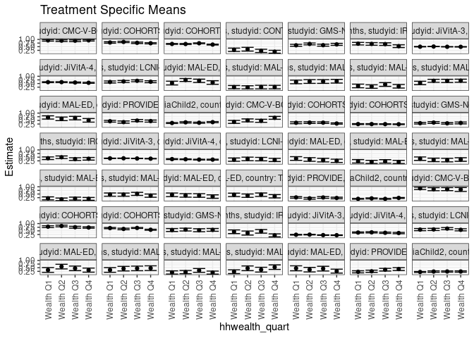

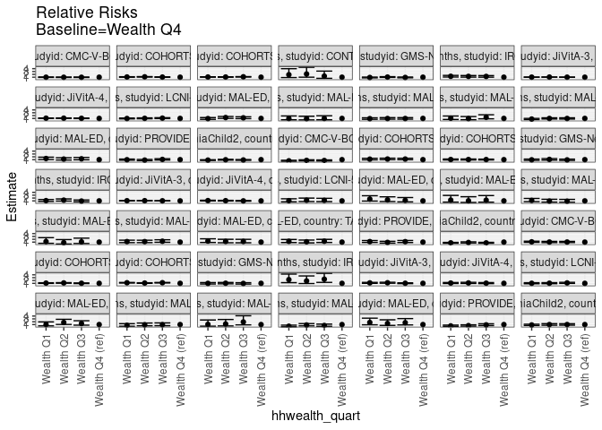

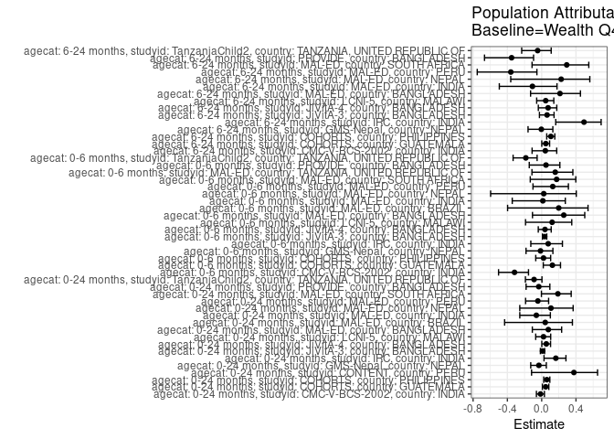

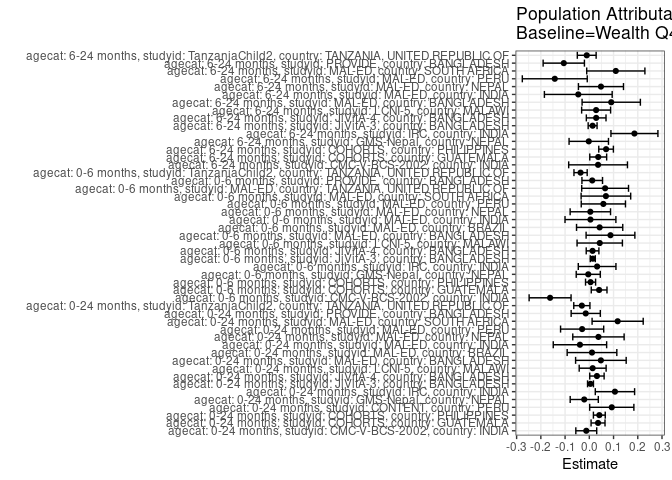

## Results Table

### Parameter: TSM

| agecat | studyid | country | intervention_level | baseline_level | estimate | ci_lower | ci_upper |
| --- | --- | --- | --- | --- | --- | --- | --- |
| 0-24 months | CMC-V-BCS-2002 | INDIA | Wealth Q4 | NA | 0.9375000 | 0.8890135 | 0.9859865 |
| 0-24 months | CMC-V-BCS-2002 | INDIA | Wealth Q1 | NA | 0.9340659 | 0.8830091 | 0.9851228 |
| 0-24 months | CMC-V-BCS-2002 | INDIA | Wealth Q2 | NA | 0.9157895 | 0.8598717 | 0.9717073 |
| 0-24 months | CMC-V-BCS-2002 | INDIA | Wealth Q3 | NA | 0.9120879 | 0.8538303 | 0.9703456 |
| 0-24 months | COHORTS | GUATEMALA | Wealth Q4 | NA | 0.7354832 | 0.6970331 | 0.7739333 |
| 0-24 months | COHORTS | GUATEMALA | Wealth Q1 | NA | 0.7889500 | 0.7404098 | 0.8374902 |
| 0-24 months | COHORTS | GUATEMALA | Wealth Q2 | NA | 0.8278300 | 0.7827973 | 0.8728626 |
| 0-24 months | COHORTS | GUATEMALA | Wealth Q3 | NA | 0.7676359 | 0.7206182 | 0.8146536 |
| 0-24 months | COHORTS | PHILIPPINES | Wealth Q4 | NA | 0.6452795 | 0.6153789 | 0.6751801 |
| 0-24 months | COHORTS | PHILIPPINES | Wealth Q1 | NA | 0.6881339 | 0.6544866 | 0.7217812 |
| 0-24 months | COHORTS | PHILIPPINES | Wealth Q2 | NA | 0.6845214 | 0.6472625 | 0.7217803 |
| 0-24 months | COHORTS | PHILIPPINES | Wealth Q3 | NA | 0.7349584 | 0.7082776 | 0.7616392 |
| 0-24 months | CONTENT | PERU | Wealth Q4 | NA | 0.1538462 | 0.0555522 | 0.2521401 |
| 0-24 months | CONTENT | PERU | Wealth Q1 | NA | 0.2881356 | 0.1723028 | 0.4039684 |
| 0-24 months | CONTENT | PERU | Wealth Q2 | NA | 0.3269231 | 0.1991281 | 0.4547181 |
| 0-24 months | CONTENT | PERU | Wealth Q3 | NA | 0.2115385 | 0.1002773 | 0.3227996 |
| 0-24 months | GMS-Nepal | NEPAL | Wealth Q4 | NA | 0.6598746 | 0.5913492 | 0.7283999 |
| 0-24 months | GMS-Nepal | NEPAL | Wealth Q1 | NA | 0.5955776 | 0.5288985 | 0.6622567 |
| 0-24 months | GMS-Nepal | NEPAL | Wealth Q2 | NA | 0.6895017 | 0.6264672 | 0.7525363 |
| 0-24 months | GMS-Nepal | NEPAL | Wealth Q3 | NA | 0.6044319 | 0.5365446 | 0.6723193 |
| 0-24 months | IRC | INDIA | Wealth Q4 | NA | 0.5356823 | 0.4406954 | 0.6306693 |
| 0-24 months | IRC | INDIA | Wealth Q1 | NA | 0.7064405 | 0.6188916 | 0.7939893 |
| 0-24 months | IRC | INDIA | Wealth Q2 | NA | 0.6894390 | 0.6010670 | 0.7778111 |
| 0-24 months | IRC | INDIA | Wealth Q3 | NA | 0.6775368 | 0.5881090 | 0.7669647 |
| 0-24 months | JiVitA-3 | BANGLADESH | Wealth Q4 | NA | 0.4905302 | 0.4759502 | 0.5051102 |
| 0-24 months | JiVitA-3 | BANGLADESH | Wealth Q1 | NA | 0.5001265 | 0.4847153 | 0.5155376 |
| 0-24 months | JiVitA-3 | BANGLADESH | Wealth Q2 | NA | 0.5121131 | 0.4998416 | 0.5243847 |
| 0-24 months | JiVitA-3 | BANGLADESH | Wealth Q3 | NA | 0.4946785 | 0.4825863 | 0.5067706 |
| 0-24 months | JiVitA-4 | BANGLADESH | Wealth Q4 | NA | 0.5504039 | 0.5169779 | 0.5838300 |
| 0-24 months | JiVitA-4 | BANGLADESH | Wealth Q1 | NA | 0.5938923 | 0.5640610 | 0.6237236 |

[output cut: 166 more lines]

### Parameter: E(Y)

| agecat | studyid | country | intervention_level | baseline_level | estimate | ci_lower | ci_upper |
| --- | --- | --- | --- | --- | --- | --- | --- |
| 0-24 months | CMC-V-BCS-2002 | INDIA | NA | NA | 0.9249330 | 0.8981563 | 0.9517096 |
| 0-24 months | COHORTS | GUATEMALA | NA | NA | 0.7715180 | 0.7484902 | 0.7945458 |
| 0-24 months | COHORTS | PHILIPPINES | NA | NA | 0.6866209 | 0.6701747 | 0.7030670 |
| 0-24 months | CONTENT | PERU | NA | NA | 0.2465116 | 0.1887688 | 0.3042545 |
| 0-24 months | GMS-Nepal | NEPAL | NA | NA | 0.6389685 | 0.6033115 | 0.6746254 |
| 0-24 months | IRC | INDIA | NA | NA | 0.6414634 | 0.5949863 | 0.6879405 |
| 0-24 months | JiVitA-3 | BANGLADESH | NA | NA | 0.4954233 | 0.4875870 | 0.5032596 |
| 0-24 months | JiVitA-4 | BANGLADESH | NA | NA | 0.5818282 | 0.5658219 | 0.5978346 |
| 0-24 months | LCNI-5 | MALAWI | NA | NA | 0.6376989 | 0.6047193 | 0.6706785 |
| 0-24 months | MAL-ED | BANGLADESH | NA | NA | 0.6157025 | 0.5542897 | 0.6771153 |
| 0-24 months | MAL-ED | BRAZIL | NA | NA | 0.2666667 | 0.2067138 | 0.3266195 |
| 0-24 months | MAL-ED | INDIA | NA | NA | 0.6212766 | 0.5591262 | 0.6834270 |
| 0-24 months | MAL-ED | NEPAL | NA | NA | 0.3474576 | 0.2865784 | 0.4083369 |
| 0-24 months | MAL-ED | PERU | NA | NA | 0.6654412 | 0.6092647 | 0.7216177 |
| 0-24 months | MAL-ED | SOUTH AFRICA | NA | NA | 0.6186770 | 0.5591785 | 0.6781756 |
| 0-24 months | PROVIDE | BANGLADESH | NA | NA | 0.4357143 | 0.3989556 | 0.4724730 |
| 0-24 months | TanzaniaChild2 | TANZANIA, UNITED REPUBLIC OF | NA | NA | 0.3468960 | 0.3277853 | 0.3660067 |
| 0-6 months | CMC-V-BCS-2002 | INDIA | NA | NA | 0.5108696 | 0.4597270 | 0.5620121 |
| 0-6 months | COHORTS | GUATEMALA | NA | NA | 0.3240116 | 0.2955133 | 0.3525098 |
| 0-6 months | COHORTS | PHILIPPINES | NA | NA | 0.2391233 | 0.2240003 | 0.2542464 |
| 0-6 months | GMS-Nepal | NEPAL | NA | NA | 0.3180516 | 0.2834770 | 0.3526261 |
| 0-6 months | IRC | INDIA | NA | NA | 0.4243902 | 0.3764905 | 0.4722900 |
| 0-6 months | JiVitA-3 | BANGLADESH | NA | NA | 0.4130891 | 0.4056400 | 0.4205383 |
| 0-6 months | JiVitA-4 | BANGLADESH | NA | NA | 0.3474692 | 0.3322601 | 0.3626783 |
| 0-6 months | LCNI-5 | MALAWI | NA | NA | 0.3531599 | 0.2959376 | 0.4103821 |
| 0-6 months | MAL-ED | BANGLADESH | NA | NA | 0.3388430 | 0.2790857 | 0.3986003 |
| 0-6 months | MAL-ED | BRAZIL | NA | NA | 0.2142857 | 0.1586564 | 0.2699151 |
| 0-6 months | MAL-ED | INDIA | NA | NA | 0.3446809 | 0.2837868 | 0.4055749 |
| 0-6 months | MAL-ED | NEPAL | NA | NA | 0.1737288 | 0.1252880 | 0.2221696 |
| 0-6 months | MAL-ED | PERU | NA | NA | 0.4485294 | 0.3893160 | 0.5077428 |
| 0-6 months | MAL-ED | SOUTH AFRICA | NA | NA | 0.3929961 | 0.3331663 | 0.4528260 |
| 0-6 months | MAL-ED | TANZANIA, UNITED REPUBLIC OF | NA | NA | 0.4120000 | 0.3508656 | 0.4731344 |
| 0-6 months | PROVIDE | BANGLADESH | NA | NA | 0.2400000 | 0.2083392 | 0.2716608 |
| 0-6 months | TanzaniaChild2 | TANZANIA, UNITED REPUBLIC OF | NA | NA | 0.1950503 | 0.1791413 | 0.2109594 |
| 6-24 months | CMC-V-BCS-2002 | INDIA | NA | NA | 0.8486486 | 0.7968646 | 0.9004327 |
| 6-24 months | COHORTS | GUATEMALA | NA | NA | 0.7665094 | 0.7380190 | 0.7949999 |
| 6-24 months | COHORTS | PHILIPPINES | NA | NA | 0.6449788 | 0.6246093 | 0.6653483 |
| 6-24 months | GMS-Nepal | NEPAL | NA | NA | 0.5642317 | 0.5153938 | 0.6130696 |
| 6-24 months | IRC | INDIA | NA | NA | 0.3771186 | 0.3151523 | 0.4390850 |
| 6-24 months | JiVitA-3 | BANGLADESH | NA | NA | 0.2161518 | 0.2067762 | 0.2255274 |
| 6-24 months | JiVitA-4 | BANGLADESH | NA | NA | 0.3784303 | 0.3598372 | 0.3970234 |
| 6-24 months | LCNI-5 | MALAWI | NA | NA | 0.6000000 | 0.5639396 | 0.6360604 |
| 6-24 months | MAL-ED | BANGLADESH | NA | NA | 0.4240506 | 0.3467471 | 0.5013542 |
| 6-24 months | MAL-ED | INDIA | NA | NA | 0.4220779 | 0.3438191 | 0.5003367 |
| 6-24 months | MAL-ED | NEPAL | NA | NA | 0.2113402 | 0.1537425 | 0.2689379 |
| 6-24 months | MAL-ED | PERU | NA | NA | 0.3959732 | 0.3171819 | 0.4747644 |
| 6-24 months | MAL-ED | SOUTH AFRICA | NA | NA | 0.3741935 | 0.2977649 | 0.4506221 |
| 6-24 months | PROVIDE | BANGLADESH | NA | NA | 0.3004386 | 0.2583143 | 0.3425629 |
| 6-24 months | TanzaniaChild2 | TANZANIA, UNITED REPUBLIC OF | NA | NA | 0.2268170 | 0.2062654 | 0.2473687 |

### Parameter: RR

| agecat | studyid | country | intervention_level | baseline_level | estimate | ci_lower | ci_upper |
| --- | --- | --- | --- | --- | --- | --- | --- |
| 0-24 months | CMC-V-BCS-2002 | INDIA | Wealth Q4 | Wealth Q4 | 1.0000000 | 1.0000000 | 1.0000000 |
| 0-24 months | CMC-V-BCS-2002 | INDIA | Wealth Q1 | Wealth Q4 | 0.9963370 | 0.9241135 | 1.0742051 |
| 0-24 months | CMC-V-BCS-2002 | INDIA | Wealth Q2 | Wealth Q4 | 0.9768421 | 0.9017212 | 1.0582212 |
| 0-24 months | CMC-V-BCS-2002 | INDIA | Wealth Q3 | Wealth Q4 | 0.9728938 | 0.8961328 | 1.0562300 |
| 0-24 months | COHORTS | GUATEMALA | Wealth Q4 | Wealth Q4 | 1.0000000 | 1.0000000 | 1.0000000 |
| 0-24 months | COHORTS | GUATEMALA | Wealth Q1 | Wealth Q4 | 1.0726961 | 0.9906375 | 1.1615520 |
| 0-24 months | COHORTS | GUATEMALA | Wealth Q2 | Wealth Q4 | 1.1255593 | 1.0445005 | 1.2129087 |
| 0-24 months | COHORTS | GUATEMALA | Wealth Q3 | Wealth Q4 | 1.0437164 | 0.9643435 | 1.1296224 |
| 0-24 months | COHORTS | PHILIPPINES | Wealth Q4 | Wealth Q4 | 1.0000000 | 1.0000000 | 1.0000000 |
| 0-24 months | COHORTS | PHILIPPINES | Wealth Q1 | Wealth Q4 | 1.0664121 | 0.9984320 | 1.1390208 |
| 0-24 months | COHORTS | PHILIPPINES | Wealth Q2 | Wealth Q4 | 1.0608138 | 0.9894413 | 1.1373347 |
| 0-24 months | COHORTS | PHILIPPINES | Wealth Q3 | Wealth Q4 | 1.1389768 | 1.0756395 | 1.2060437 |
| 0-24 months | CONTENT | PERU | Wealth Q4 | Wealth Q4 | 1.0000000 | 1.0000000 | 1.0000000 |
| 0-24 months | CONTENT | PERU | Wealth Q1 | Wealth Q4 | 1.8728814 | 0.8803953 | 3.9842154 |
| 0-24 months | CONTENT | PERU | Wealth Q2 | Wealth Q4 | 2.1250000 | 1.0047762 | 4.4941600 |
| 0-24 months | CONTENT | PERU | Wealth Q3 | Wealth Q4 | 1.3750000 | 0.6010371 | 3.1456043 |
| 0-24 months | GMS-Nepal | NEPAL | Wealth Q4 | Wealth Q4 | 1.0000000 | 1.0000000 | 1.0000000 |
| 0-24 months | GMS-Nepal | NEPAL | Wealth Q1 | Wealth Q4 | 0.9025618 | 0.7774471 | 1.0478112 |
| 0-24 months | GMS-Nepal | NEPAL | Wealth Q2 | Wealth Q4 | 1.0448981 | 0.9132316 | 1.1955479 |
| 0-24 months | GMS-Nepal | NEPAL | Wealth Q3 | Wealth Q4 | 0.9159800 | 0.7887120 | 1.0637842 |
| 0-24 months | IRC | INDIA | Wealth Q4 | Wealth Q4 | 1.0000000 | 1.0000000 | 1.0000000 |
| 0-24 months | IRC | INDIA | Wealth Q1 | Wealth Q4 | 1.3187675 | 1.0646915 | 1.6334758 |
| 0-24 months | IRC | INDIA | Wealth Q2 | Wealth Q4 | 1.2870296 | 1.0366114 | 1.5979424 |
| 0-24 months | IRC | INDIA | Wealth Q3 | Wealth Q4 | 1.2648109 | 1.0155087 | 1.5753155 |
| 0-24 months | JiVitA-3 | BANGLADESH | Wealth Q4 | Wealth Q4 | 1.0000000 | 1.0000000 | 1.0000000 |
| 0-24 months | JiVitA-3 | BANGLADESH | Wealth Q1 | Wealth Q4 | 1.0195631 | 0.9809667 | 1.0596781 |
| 0-24 months | JiVitA-3 | BANGLADESH | Wealth Q2 | Wealth Q4 | 1.0439992 | 1.0092886 | 1.0799036 |
| 0-24 months | JiVitA-3 | BANGLADESH | Wealth Q3 | Wealth Q4 | 1.0084567 | 0.9746281 | 1.0434595 |
| 0-24 months | JiVitA-4 | BANGLADESH | Wealth Q4 | Wealth Q4 | 1.0000000 | 1.0000000 | 1.0000000 |
| 0-24 months | JiVitA-4 | BANGLADESH | Wealth Q1 | Wealth Q4 | 1.0790118 | 1.0001824 | 1.1640541 |

[output cut: 166 more lines]

### Parameter: PAR

| agecat | studyid | country | intervention_level | baseline_level | estimate | ci_lower | ci_upper |
| --- | --- | --- | --- | --- | --- | --- | --- |
| 0-24 months | CMC-V-BCS-2002 | INDIA | Wealth Q4 | NA | -0.0125670 | -0.0556692 | 0.0305351 |
| 0-24 months | COHORTS | GUATEMALA | Wealth Q4 | NA | 0.0360348 | 0.0072823 | 0.0647872 |
| 0-24 months | COHORTS | PHILIPPINES | Wealth Q4 | NA | 0.0413414 | 0.0169052 | 0.0657775 |
| 0-24 months | CONTENT | PERU | Wealth Q4 | NA | 0.0926655 | 0.0014385 | 0.1838925 |
| 0-24 months | GMS-Nepal | NEPAL | Wealth Q4 | NA | -0.0209061 | -0.0789005 | 0.0370883 |
| 0-24 months | IRC | INDIA | Wealth Q4 | NA | 0.1057811 | 0.0246822 | 0.1868800 |
| 0-24 months | JiVitA-3 | BANGLADESH | Wealth Q4 | NA | 0.0048931 | -0.0072998 | 0.0170860 |
| 0-24 months | JiVitA-4 | BANGLADESH | Wealth Q4 | NA | 0.0314243 | 0.0017483 | 0.0611003 |
| 0-24 months | LCNI-5 | MALAWI | Wealth Q4 | NA | 0.0138164 | -0.0417559 | 0.0693887 |
| 0-24 months | MAL-ED | BANGLADESH | Wealth Q4 | NA | 0.0477922 | -0.0565774 | 0.1521618 |
| 0-24 months | MAL-ED | BRAZIL | Wealth Q4 | NA | 0.0110572 | -0.0914158 | 0.1135302 |
| 0-24 months | MAL-ED | INDIA | Wealth Q4 | NA | -0.0386468 | -0.1488003 | 0.0715067 |
| 0-24 months | MAL-ED | NEPAL | Wealth Q4 | NA | 0.0376907 | -0.0682398 | 0.1436213 |
| 0-24 months | MAL-ED | PERU | Wealth Q4 | NA | -0.0296658 | -0.1186380 | 0.0593065 |
| 0-24 months | MAL-ED | SOUTH AFRICA | Wealth Q4 | NA | 0.1169290 | 0.0114575 | 0.2224005 |
| 0-24 months | PROVIDE | BANGLADESH | Wealth Q4 | NA | -0.0147784 | -0.0749595 | 0.0454026 |
| 0-24 months | TanzaniaChild2 | TANZANIA, UNITED REPUBLIC OF | Wealth Q4 | NA | -0.0307965 | -0.0641830 | 0.0025899 |
| 0-6 months | CMC-V-BCS-2002 | INDIA | Wealth Q4 | NA | -0.1618267 | -0.2483587 | -0.0752947 |
| 0-6 months | COHORTS | GUATEMALA | Wealth Q4 | NA | 0.0404793 | 0.0080404 | 0.0729182 |
| 0-6 months | COHORTS | PHILIPPINES | Wealth Q4 | NA | 0.0051813 | -0.0155856 | 0.0259481 |
| 0-6 months | GMS-Nepal | NEPAL | Wealth Q4 | NA | -0.0043681 | -0.0540185 | 0.0452823 |
| 0-6 months | IRC | INDIA | Wealth Q4 | NA | 0.0322191 | -0.0454761 | 0.1099144 |
| 0-6 months | JiVitA-3 | BANGLADESH | Wealth Q4 | NA | 0.0143440 | 0.0040648 | 0.0246232 |
| 0-6 months | JiVitA-4 | BANGLADESH | Wealth Q4 | NA | 0.0134095 | -0.0127569 | 0.0395758 |
| 0-6 months | LCNI-5 | MALAWI | Wealth Q4 | NA | 0.0430267 | -0.0505610 | 0.1366144 |
| 0-6 months | MAL-ED | BANGLADESH | Wealth Q4 | NA | 0.0873482 | -0.0132652 | 0.1879617 |
| 0-6 months | MAL-ED | BRAZIL | Wealth Q4 | NA | 0.0426019 | -0.0527701 | 0.1379738 |
| 0-6 months | MAL-ED | INDIA | Wealth Q4 | NA | 0.0047028 | -0.1002907 | 0.1096964 |
| 0-6 months | MAL-ED | NEPAL | Wealth Q4 | NA | 0.0042373 | -0.0791207 | 0.0875953 |
| 0-6 months | MAL-ED | PERU | Wealth Q4 | NA | 0.0579840 | -0.0332981 | 0.1492661 |
| 0-6 months | MAL-ED | SOUTH AFRICA | Wealth Q4 | NA | 0.0684653 | -0.0338057 | 0.1707362 |
| 0-6 months | MAL-ED | TANZANIA, UNITED REPUBLIC OF | Wealth Q4 | NA | 0.0651963 | -0.0314026 | 0.1617952 |
| 0-6 months | PROVIDE | BANGLADESH | Wealth Q4 | NA | 0.0120734 | -0.0304584 | 0.0546053 |
| 0-6 months | TanzaniaChild2 | TANZANIA, UNITED REPUBLIC OF | Wealth Q4 | NA | -0.0360751 | -0.0633629 | -0.0087873 |
| 6-24 months | CMC-V-BCS-2002 | INDIA | Wealth Q4 | NA | 0.0361486 | -0.0851282 | 0.1574255 |
| 6-24 months | COHORTS | GUATEMALA | Wealth Q4 | NA | 0.0367273 | 0.0018833 | 0.0715713 |
| 6-24 months | COHORTS | PHILIPPINES | Wealth Q4 | NA | 0.0692033 | 0.0389888 | 0.0994179 |
| 6-24 months | GMS-Nepal | NEPAL | Wealth Q4 | NA | -0.0022237 | -0.0835201 | 0.0790726 |
| 6-24 months | IRC | INDIA | Wealth Q4 | NA | 0.1861811 | 0.0892573 | 0.2831048 |
| 6-24 months | JiVitA-3 | BANGLADESH | Wealth Q4 | NA | 0.0136047 | -0.0047809 | 0.0319903 |
| 6-24 months | JiVitA-4 | BANGLADESH | Wealth Q4 | NA | 0.0283298 | -0.0122688 | 0.0689285 |
| 6-24 months | LCNI-5 | MALAWI | Wealth Q4 | NA | 0.0280924 | -0.0316724 | 0.0878572 |
| 6-24 months | MAL-ED | BANGLADESH | Wealth Q4 | NA | 0.0904522 | -0.0298161 | 0.2107204 |
| 6-24 months | MAL-ED | INDIA | Wealth Q4 | NA | -0.0455017 | -0.1853488 | 0.0943454 |
| 6-24 months | MAL-ED | NEPAL | Wealth Q4 | NA | 0.0480749 | -0.0449018 | 0.1410516 |
| 6-24 months | MAL-ED | PERU | Wealth Q4 | NA | -0.1424884 | -0.2764712 | -0.0085056 |
| 6-24 months | MAL-ED | SOUTH AFRICA | Wealth Q4 | NA | 0.1093469 | -0.0107227 | 0.2294164 |
| 6-24 months | PROVIDE | BANGLADESH | Wealth Q4 | NA | -0.1053554 | -0.1905373 | -0.0201735 |
| 6-24 months | TanzaniaChild2 | TANZANIA, UNITED REPUBLIC OF | Wealth Q4 | NA | -0.0106645 | -0.0495015 | 0.0281725 |

### Parameter: PAF

| agecat | studyid | country | intervention_level | baseline_level | estimate | ci_lower | ci_upper |
| --- | --- | --- | --- | --- | --- | --- | --- |
| 0-24 months | CMC-V-BCS-2002 | INDIA | Wealth Q4 | NA | -0.0135870 | -0.0613168 | 0.0319963 |
| 0-24 months | COHORTS | GUATEMALA | Wealth Q4 | NA | 0.0467064 | 0.0085412 | 0.0834024 |
| 0-24 months | COHORTS | PHILIPPINES | Wealth Q4 | NA | 0.0602099 | 0.0238589 | 0.0952072 |
| 0-24 months | CONTENT | PERU | Wealth Q4 | NA | 0.3759071 | -0.1179586 | 0.6516043 |
| 0-24 months | GMS-Nepal | NEPAL | Wealth Q4 | NA | -0.0327185 | -0.1275796 | 0.0541621 |
| 0-24 months | IRC | INDIA | Wealth Q4 | NA | 0.1649059 | 0.0272268 | 0.2830989 |
| 0-24 months | JiVitA-3 | BANGLADESH | Wealth Q4 | NA | 0.0098766 | -0.0150454 | 0.0341868 |
| 0-24 months | JiVitA-4 | BANGLADESH | Wealth Q4 | NA | 0.0540096 | 0.0016143 | 0.1036552 |
| 0-24 months | LCNI-5 | MALAWI | Wealth Q4 | NA | 0.0216660 | -0.0695201 | 0.1050777 |
| 0-24 months | MAL-ED | BANGLADESH | Wealth Q4 | NA | 0.0776223 | -0.1090393 | 0.2328669 |
| 0-24 months | MAL-ED | BRAZIL | Wealth Q4 | NA | 0.0414647 | -0.4322294 | 0.3584896 |
| 0-24 months | MAL-ED | INDIA | Wealth Q4 | NA | -0.0622055 | -0.2552307 | 0.1011370 |
| 0-24 months | MAL-ED | NEPAL | Wealth Q4 | NA | 0.1084758 | -0.2553533 | 0.3668592 |
| 0-24 months | MAL-ED | PERU | Wealth Q4 | NA | -0.0445806 | -0.1874406 | 0.0810920 |
| 0-24 months | MAL-ED | SOUTH AFRICA | Wealth Q4 | NA | 0.1889984 | -0.0029820 | 0.3442320 |
| 0-24 months | PROVIDE | BANGLADESH | Wealth Q4 | NA | -0.0339177 | -0.1816172 | 0.0953198 |
| 0-24 months | TanzaniaChild2 | TANZANIA, UNITED REPUBLIC OF | Wealth Q4 | NA | -0.0887774 | -0.1894322 | 0.0033595 |
| 0-6 months | CMC-V-BCS-2002 | INDIA | Wealth Q4 | NA | -0.3167672 | -0.5029281 | -0.1536652 |
| 0-6 months | COHORTS | GUATEMALA | Wealth Q4 | NA | 0.1249317 | 0.0188139 | 0.2195727 |
| 0-6 months | COHORTS | PHILIPPINES | Wealth Q4 | NA | 0.0216677 | -0.0690737 | 0.1047071 |
| 0-6 months | GMS-Nepal | NEPAL | Wealth Q4 | NA | -0.0137340 | -0.1824632 | 0.1309187 |
| 0-6 months | IRC | INDIA | Wealth Q4 | NA | 0.0759187 | -0.1266342 | 0.2420554 |
| 0-6 months | JiVitA-3 | BANGLADESH | Wealth Q4 | NA | 0.0347238 | 0.0094850 | 0.0593195 |
| 0-6 months | JiVitA-4 | BANGLADESH | Wealth Q4 | NA | 0.0385918 | -0.0397397 | 0.1110220 |
| 0-6 months | LCNI-5 | MALAWI | Wealth Q4 | NA | 0.1218334 | -0.1880025 | 0.3508629 |
| 0-6 months | MAL-ED | BANGLADESH | Wealth Q4 | NA | 0.2577838 | -0.1070775 | 0.5023972 |
| 0-6 months | MAL-ED | BRAZIL | Wealth Q4 | NA | 0.1988087 | -0.3974212 | 0.5406485 |
| 0-6 months | MAL-ED | INDIA | Wealth Q4 | NA | 0.0136440 | -0.3433405 | 0.2757621 |
| 0-6 months | MAL-ED | NEPAL | Wealth Q4 | NA | 0.0243902 | -0.5953455 | 0.4033804 |
| 0-6 months | MAL-ED | PERU | Wealth Q4 | NA | 0.1292758 | -0.1014041 | 0.3116418 |
| 0-6 months | MAL-ED | SOUTH AFRICA | Wealth Q4 | NA | 0.1742136 | -0.1331785 | 0.3982208 |
| 0-6 months | MAL-ED | TANZANIA, UNITED REPUBLIC OF | Wealth Q4 | NA | 0.1582434 | -0.1134476 | 0.3636395 |
| 0-6 months | PROVIDE | BANGLADESH | Wealth Q4 | NA | 0.0503060 | -0.1447850 | 0.2121501 |
| 0-6 months | TanzaniaChild2 | TANZANIA, UNITED REPUBLIC OF | Wealth Q4 | NA | -0.1849528 | -0.3332853 | -0.0531227 |
| 6-24 months | CMC-V-BCS-2002 | INDIA | Wealth Q4 | NA | 0.0425955 | -0.1117937 | 0.1755455 |
| 6-24 months | COHORTS | GUATEMALA | Wealth Q4 | NA | 0.0479150 | 0.0011776 | 0.0924653 |
| 6-24 months | COHORTS | PHILIPPINES | Wealth Q4 | NA | 0.1072955 | 0.0589797 | 0.1531306 |
| 6-24 months | GMS-Nepal | NEPAL | Wealth Q4 | NA | -0.0039412 | -0.1588776 | 0.1302810 |
| 6-24 months | IRC | INDIA | Wealth Q4 | NA | 0.4936936 | 0.1639423 | 0.6933869 |
| 6-24 months | JiVitA-3 | BANGLADESH | Wealth Q4 | NA | 0.0629406 | -0.0260176 | 0.1441860 |
| 6-24 months | JiVitA-4 | BANGLADESH | Wealth Q4 | NA | 0.0748614 | -0.0390479 | 0.1762830 |
| 6-24 months | LCNI-5 | MALAWI | Wealth Q4 | NA | 0.0468206 | -0.0582747 | 0.1414792 |
| 6-24 months | MAL-ED | BANGLADESH | Wealth Q4 | NA | 0.2133051 | -0.1294072 | 0.4520233 |
| 6-24 months | MAL-ED | INDIA | Wealth Q4 | NA | -0.1078040 | -0.4941395 | 0.1786378 |
| 6-24 months | MAL-ED | NEPAL | Wealth Q4 | NA | 0.2274764 | -0.3607913 | 0.5614369 |
| 6-24 months | MAL-ED | PERU | Wealth Q4 | NA | -0.3598435 | -0.7515813 | -0.0557172 |
| 6-24 months | MAL-ED | SOUTH AFRICA | Wealth Q4 | NA | 0.2922201 | -0.1121749 | 0.5495742 |
| 6-24 months | PROVIDE | BANGLADESH | Wealth Q4 | NA | -0.3506719 | -0.6666811 | -0.0945792 |
| 6-24 months | TanzaniaChild2 | TANZANIA, UNITED REPUBLIC OF | Wealth Q4 | NA | -0.0470183 | -0.2329907 | 0.1109039 |